# crasch

1 November 2016

## Introduction

## Objectives

- Learn how to obtain the development version of `crasch`
- View "standard output" provided by the package
- Provide feedback and suggestions for future development

## Basics

- What is `crasch`?
  - `crasch` is an `R` package written to accompany *Constructing Measures* (Wilson, 2005).
  - It is also the (future) reporting engine for the Berkeley Assessment System Software http://bass.bearapps.org/.
- What is an `R` package?
  - Freely available code for use in `R` written, maintained, and made available by an `R` user.
- What is `R`?
  - `R` is free statistical software (Mac, PC, or Unix) for computing and graphic production.
  - https://www.r-project.org

## IRT in `R`

Item response theory (IRT) requires specialized statistical analyses, and these types of functions are not included in the base `R` libraries.

The following packages are well-documented and widely used for IRT analyses.

- mirt (Chalmers, 2012)
- **TAM** (Kiefer, Robitzsch, & Wu, 2015)
- eRm (Mair, Hatzinger, & Maier, 2015)
- ltm (Rizopoulos, 2006)
- **WrightMap** (Torres Irribarra & Freund, 2014)

## `R` and RStudio

- Download and install `R`:
  - OSX: http://cran.cnr.berkeley.edu/bin/macosx/
  - Win: http://cran.cnr.berkeley.edu/bin/windows/base/
  - Linux: http://cran.cnr.berkeley.edu/bin/linux/
- Download and install RStudio (for a much friendlier `R` experience!)
  - https://www.rstudio.com/products/rstudio/download/
  - Choose your OS under "Installers" and proceed as you would with any software installation.
- If you already have `R` on your machine, you may need to update to the latest version. Use the links above to do so.

## Demo materials

- These slides, the associated RMarkdown file, and a script with all commands are available at https://github.com/amyarneson/BEARseminar
  - Github will render the `.Rmd` file and you can view these slides on github (just click on the `.Rmd` file!).
  - You can also view the R script (the `.R` file) on github.
  - To download materials: click the green "Clone or download" button and click "Download ZIP."

## Installing `crasch`

```r
# This first package allows you to install from github
install.packages("devtools")

# Install crasch
devtools::install_github("amyarneson/crasch")
# This may take a few minutes; multiple packages will be installed
# You may see some warning messages, and that's okay!

# Use the same command to update the package as changes are made.
```

## How it works

## Input files

There are 3 required input files to run your analysis and an optional 4th:

- construct information (`consInfo`)
- item information (`itemInfo`)
- scored responses (`scores`)
- external variables (optional, `varsInfo`)

Each of these files must structured exactly as shown in this tutorial with the correct column headings. Sample data files are available at https://github.com/amyarneson/crasch-materials

*I will not be covering data files in detail today. The above link has a tutorial devoted only to making the data files.*

## Input files, cont.

The package comes with sample data sets.

The ADP data corresponds with a construct developed for a study of teacher adoption of a cross-curricular writing "program" in a Missouri public high school in 2013.

```
+ *A PDF with some more information about the construct and instrument is
  provided on github.*

+ It was Amy's 274A class project.
```

```r
library(crasch)

# You can view the input objects
View(ADPcons) # Construct information input
View(ADPitem) # Item information input
View(ADPwide) # Scores in wide format
```

## Standard analysis: Demo

## Estimation

The main function for the package is `craschR()`.

- This function calls `TAM` to perform estimation and then organizes the output in a friendly way.
- Output can be saved to your working directory in CSV format using `writeout = TRUE`.
- Save the results as an R object so that they can be used in the post-estimation functions.

```r
?craschR  # check out the argument options and description

ADP = craschR(scores = ADPwide, itemInfo = ADPitem,
              consInfo = ADPcons, varsInfo = ADPvars,
              writeout = FALSE)
```

## Estimation

The default person estimation method is EAP.

You can also obtain MLEs or WLEs.

```r
ADP_MLE = craschR(scores = ADPwide, itemInfo = ADPitem,
                  consInfo = ADPcons, varsInfo = ADPvars,
                  persMethod = "MLE", writeout = FALSE)
ADP_WLE = craschR(scores = ADPwide, itemInfo = ADPitem,
                  consInfo = ADPcons, varsInfo = ADPvars,
                  persMethod = "WLE", writeout = FALSE)

# View the different estimates in a table
cbind(ADP$persPars, ADP_MLE$persPars, ADP_WLE$persPars)
```

## Estimation

To access the output in your R session, use `$` with the name of the object you want to view.

```r
names(ADP)
```

```
##  [1] "itemPars"       "itemSEs"        "itemThres"      "itemFit"
##  [5] "persPars"       "persSEs"        "persRaw"        "persMax"
##  [9] "persFit"        "popDist"        "sepRel"         "estSummary"
## [13] "classicalStats" "empties"        "scoresOrig"     "scoresRecoded"
## [17] "itemInfo"       "consInfo"       "varsInfo"
```

See the `craschR()` help documentation for information on the format of each element of the list.

```r
View(ADP$itemPars)
View(ADP$persPars)
ADP$estSummary
```

## Post-Estimation functions

## `item.scores()`

### Produce tables and graphs for the score distribution by item

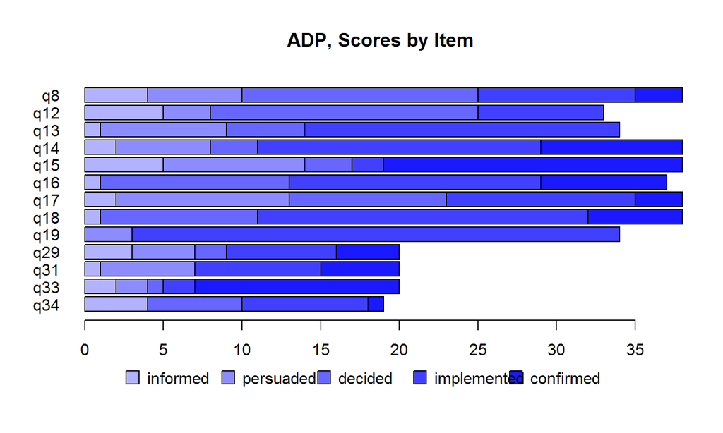

```r
?item.scores
item.scores(ADP)
```

## `item.scores()` cont.

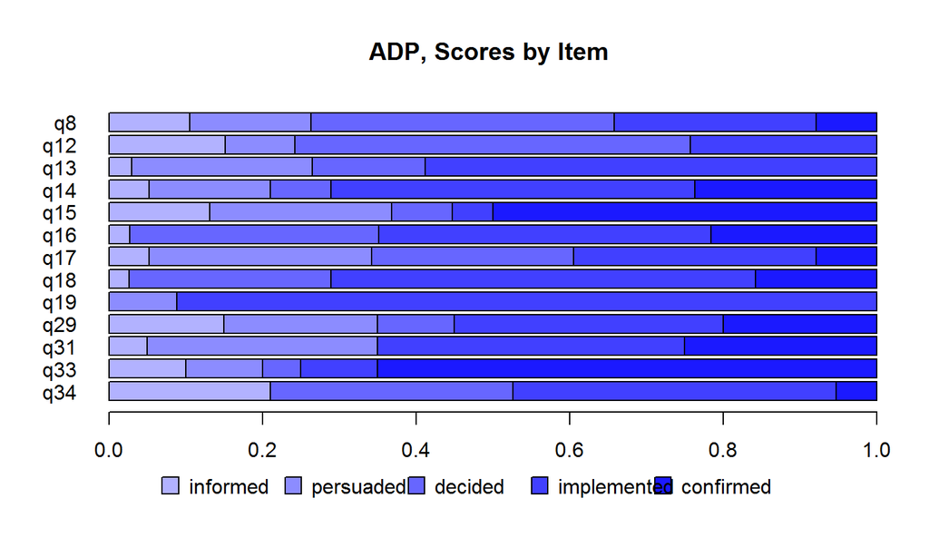

```r
# To graph proportions instead of frequencies, use freqs = FALSE
item.scores(ADP, freqs = FALSE)
```

## `item.scores()` cont.

Check out the Color Brewer website. It is really helpful in determining color palettes in general for presentations. They even have color-blind-friendly palettes if you want to make a fully-accessible presentation!

colorbrewer2.org

The `RColorBrewer` package pulls this information from the Color Brewer website. Each color scheme has a name. You can then put that scheme name into the `palette` argument in a `crasch` graphic function.

## `item.scores()` cont.

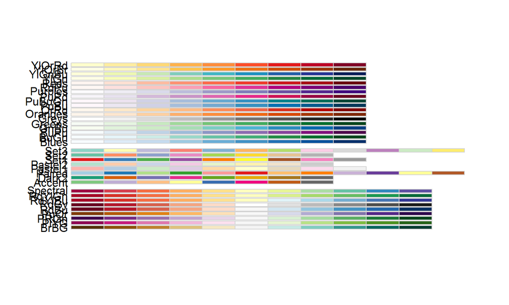

```r
display.brewer.all() # creates a graphic with the palettes displayed + names
```

## `item.scores()` cont.

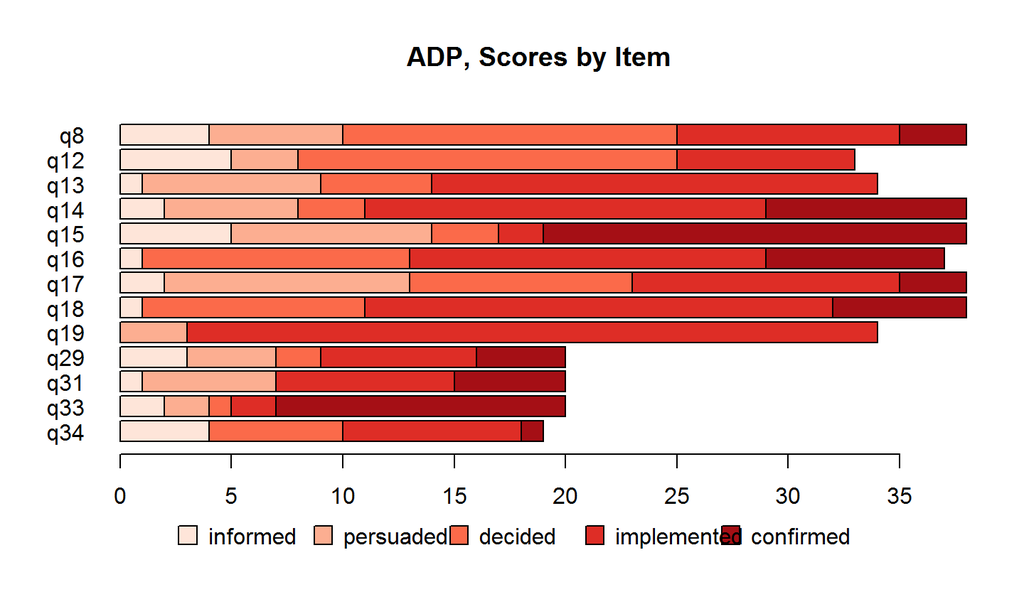

```r
item.scores(ADP, palette = "Reds")
```

## `item.scores()` cont.

### Graphic file writeout options

- PDF is the default file type, but can be difficult to work with in MS Office.
- SVGs are also supported (note that extra software may be required).
- PNGs, JPEGs, BMPs, and TIFFs are lower-quality graphics, but are easily inserted in MS doc & ppt files.

```r
item.scores(ADP, writeout = TRUE, imageType = "png")
item.scores(ADP, writeout = TRUE, imageType = "jpeg")
item.scores(ADP, writeout = TRUE, imageType = "bmp")
item.scores(ADP, writeout = TRUE, imageType = "tiff")
```

## `pers.hist()`

### Estimated person locations with a normal curve overlaid

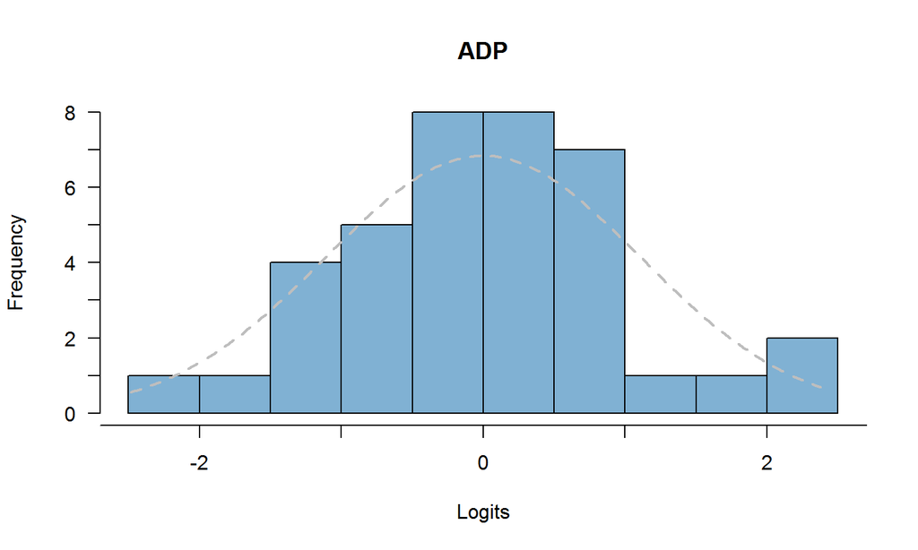

```r
?pers.hist
pers.hist(ADP)
```

## `pers.hist()` cont.

You can change the colors and the write options as shown before.

```r
pers.hist(ADP, palette = "Spectral")
# You can also specify any 2 R colors in a vector
  pers.hist(ADP, palette = c("red", "darkred"))
```

For a list of R color names: http://www.stat.columbia.edu/~tzheng/files/Rcolor.pdf

## `KIDMAP()`

### Produce a KIDMAP graphic for a given respondent

```r
?KIDMAP
# For the KIDMAP function you must specify a respondent ID!
# To look at the list of your IDs:
row.names(ADPwide)
```

```
##  [1] "110" "111" "112" "113" "114" "115" "116" "117" "118" "119" "120"
## [12] "121" "122" "123" "124" "125" "126" "127" "128" "129" "130" "131"
## [23] "132" "133" "134" "135" "136" "137" "138" "139" "140" "141" "142"
## [34] "143" "144" "145" "146" "147"
```

## `KIDMAP()` cont.

```r
KIDMAP(ADP, 120)
```

```
## No output was written to file. If you wish to write to file, use writeout=TRUE.
```

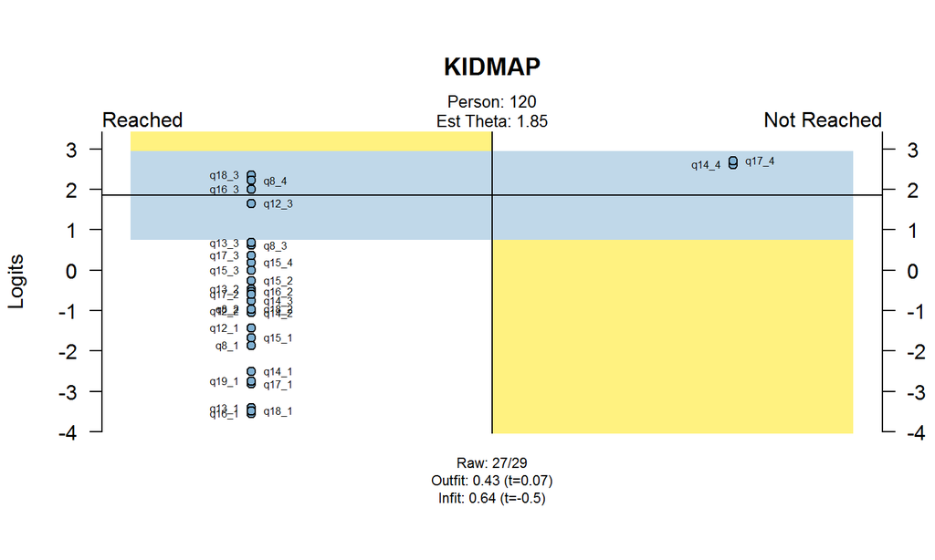

## `KIDMAP()` cont.

You can change the colors and the write options as above.

```r
KIDMAP(ADP, 120, palette = "Spectral")
# You can also specify any 3 R colors in a vector
  KIDMAP(ADP, 147, palette = c("darkred", "red", "black"))
```

## `item.analysis()`

### Produce by item and by step tables

```r
?item.analysis

item.analysis(ADP)
```

Truncated output (item table):

```
##     Item_no Construct Count Missing    Estimate    SE_est    outfit
## q8        1       ADP    38       0  0.05422447 0.2010052 1.1344913
## q12       2       ADP    33       5 -0.38480609 0.2368879 0.8864480
## q13       3       ADP    34       4 -1.60645454 0.2390831 0.7328923
##       outfit_t  outfit_p     infit    infit_t   infit_p
## q8   0.6182410 0.1341041 1.1285656  0.6076677 0.1358520
## q12 -0.3404578 0.1833779 0.8863959 -0.3958307 0.1730575
## q13 -0.4685857 0.1598415 0.8788586 -0.4731518 0.1590262
```

## `item.analysis()` cont.

Truncated output (step table):

```
##   Item Construct       Cat Count Score  Estimate    SE_est  Threshold
## 1   q8       ADP  informed     4     0        NA        NA         NA
## 2   q8       ADP persuaded     6     1 -1.443883 0.4618278 -1.8623258
## 3   q8       ADP   decided    15     2 -1.333217 0.3788430 -0.9650323
##    PtBiserial MeanPersLoc SD_PersLoc
## 1 -0.15699196  -0.5021342  0.4886113
## 2 -0.55410909  -1.2234224  0.9264868
## 3 -0.04283387  -0.1264180  0.6356938
```

## `infit.MNSQ()`

### Produce a graphic of item fit statistics

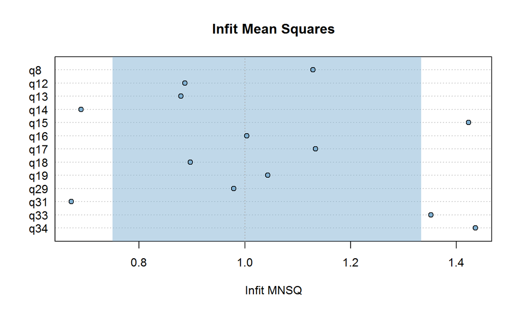

```r
?infit.MNSQ
infit.MNSQ(ADP)
```

## `infit.MNSQ()` cont.

To plot the step fit instead of the overall item fit:

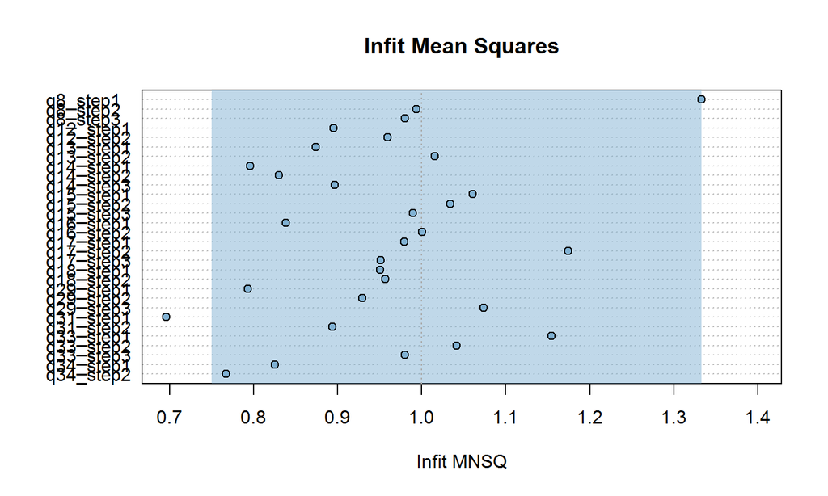

```r
infit.MNSQ(ADP, params = "steps")
```

## `infit.MNSQ()` cont.

To restrict which items are plotted on each graph:

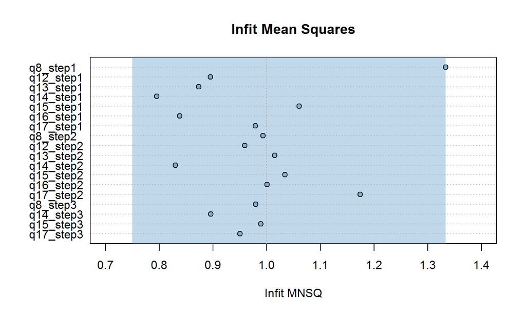

```r
infit.MNSQ(ADP, itemOrder = c(1, 2, 3, 4, 5, 6, 7), params = "steps")
```

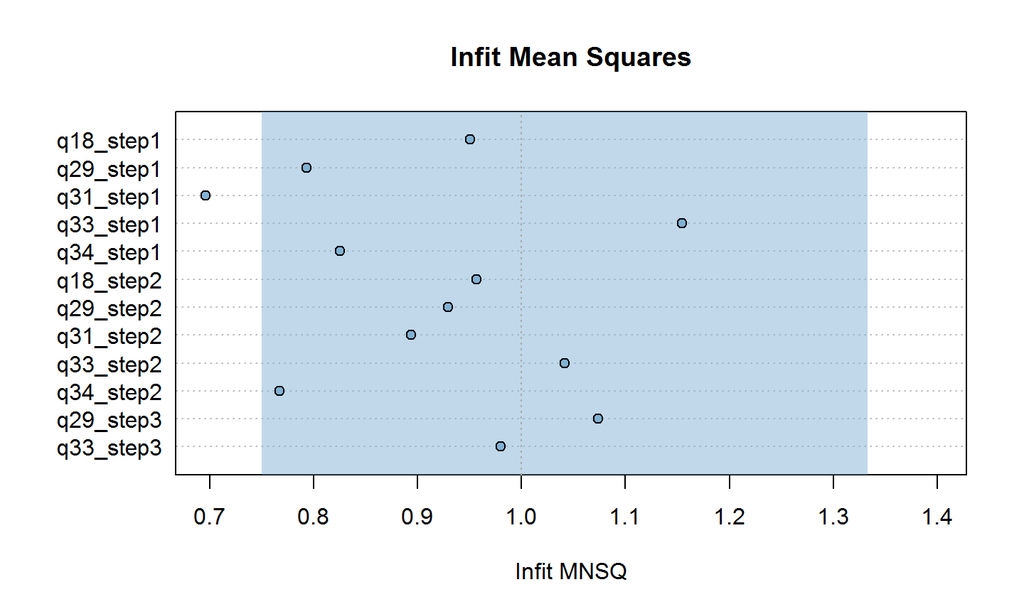

```r
infit.MNSQ(ADP, itemOrder = 8:13, params = "steps")
```

## `CPC.graph()`

### Produce graphics of cumulative probability curves

```r
?CPC.graph
CPC.graph(ADP) # Note that a separate graph is produced for each item
```

## `CPC.graph()` cont.

To selectively produce graphs use itemOrder:

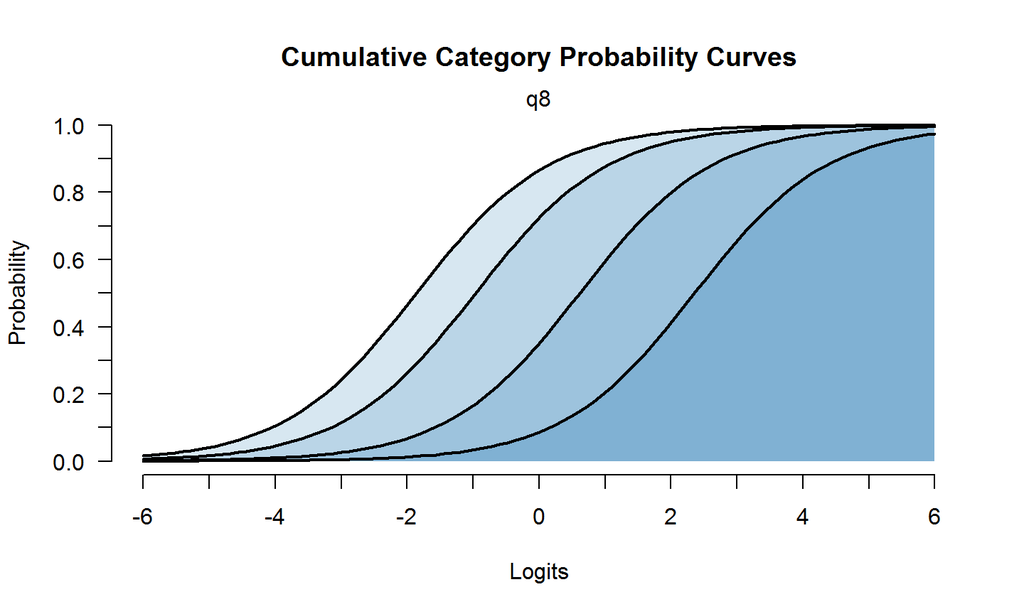

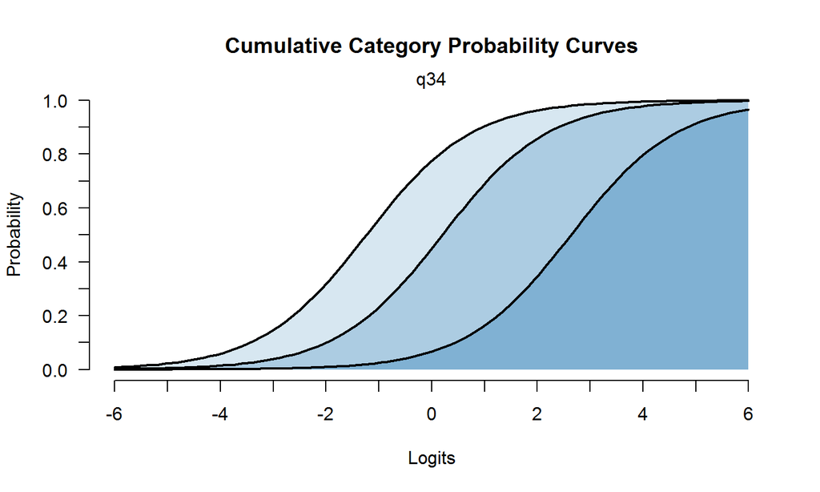

```r
CPC.graph(ADP, itemOrder = c(1, 13))
```

## `CPC.graph()` cont.

To plot your observed proportions, use observed and minCell:

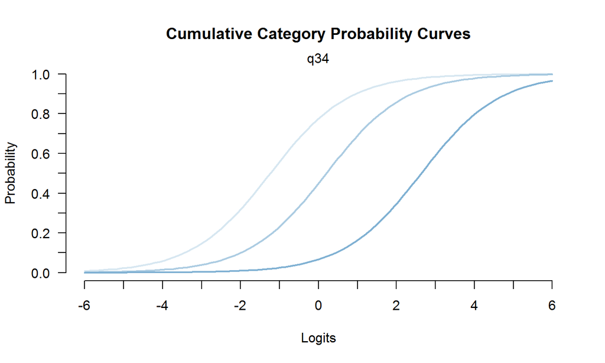

```r
CPC.graph(ADP, itemOrder = 13, observed = TRUE)
```

## `CPC.graph()` cont.

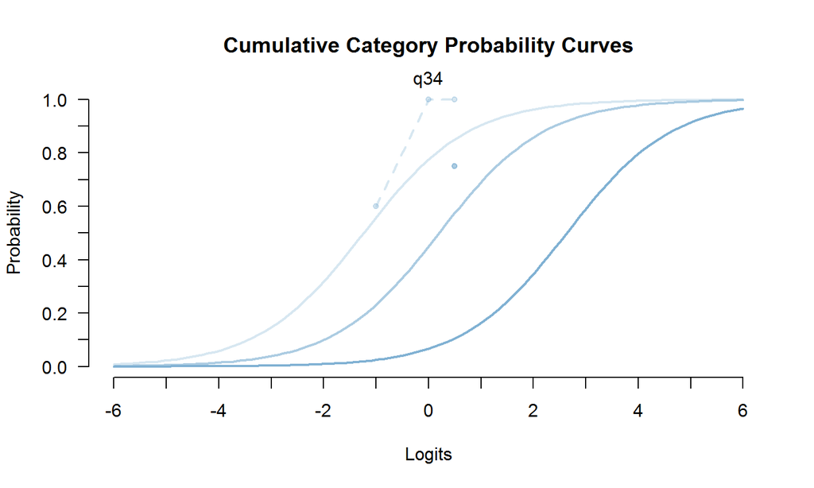

```r
CPC.graph(ADP, itemOrder = 13, observed = TRUE, minCell = 3)
```

## `CPC.graph()` cont.

You can also plot "vertically" as in Wilson (2005)!

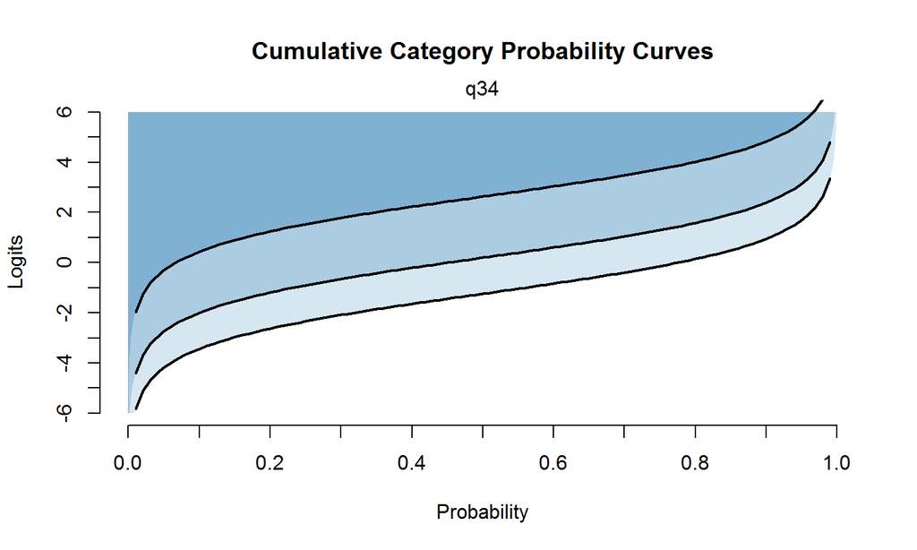

```r
CPC.graph(ADP, itemOrder = 13, logitAxis = "y")
```

## `ICC.graph()`

### Produce graphics of the item (or category) characteristic curves

```r
?ICC.graph

ICC.graph(ADP) # produces a graph for each item
```

## `ICC.graph()` cont.

itemOrder works as in the CPC.graph() function

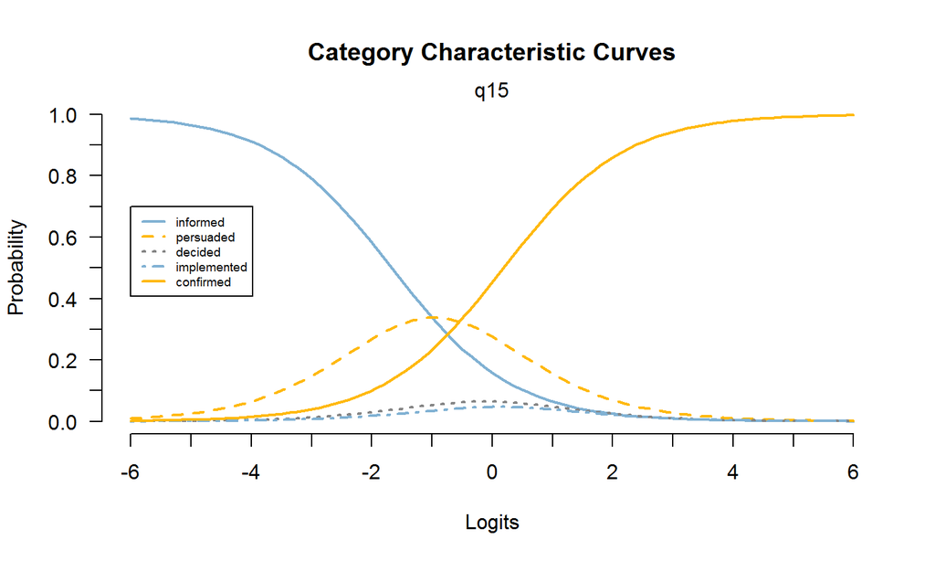

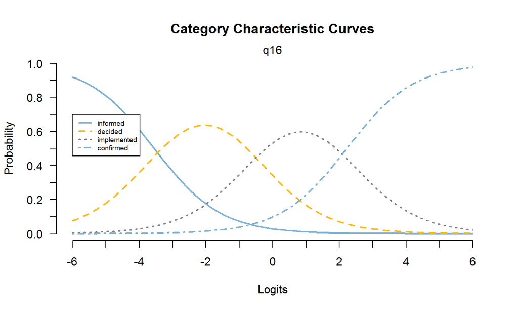

```r
ICC.graph(ADP, itemOrder = c(5:6))
```

## `info.graph()`

### Produce graphics of test and item information

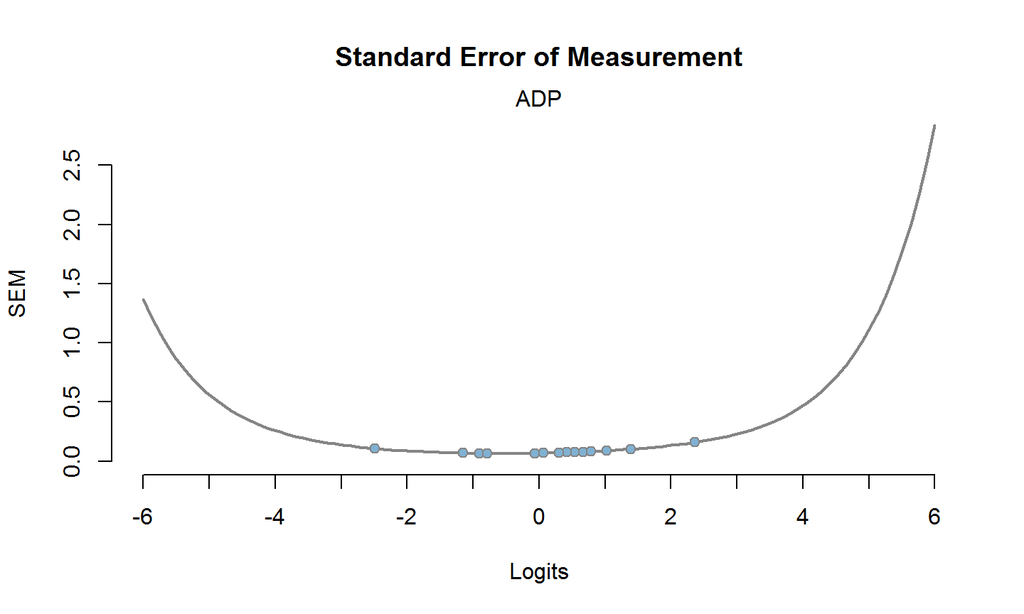

```r
?info.graph
info.graph(ADP, type = "SEM")  # SEM is the default
```

## `info.graph()` cont.

You can plot all observations (even incomplete ones) using `completeOnly = FALSE`

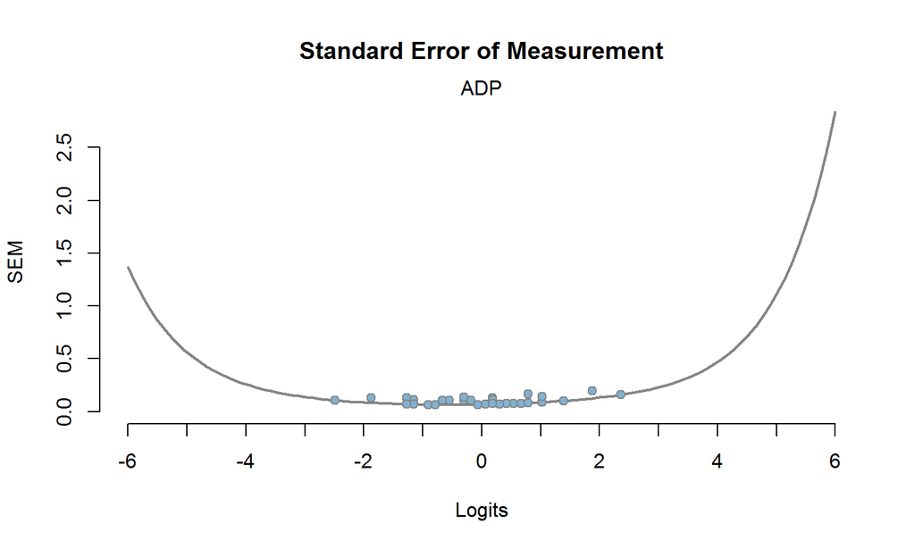

```r
info.graph(ADP, type = "SEM", completeOnly = FALSE)
```

## `info.graph()` cont.

For the test information curve:

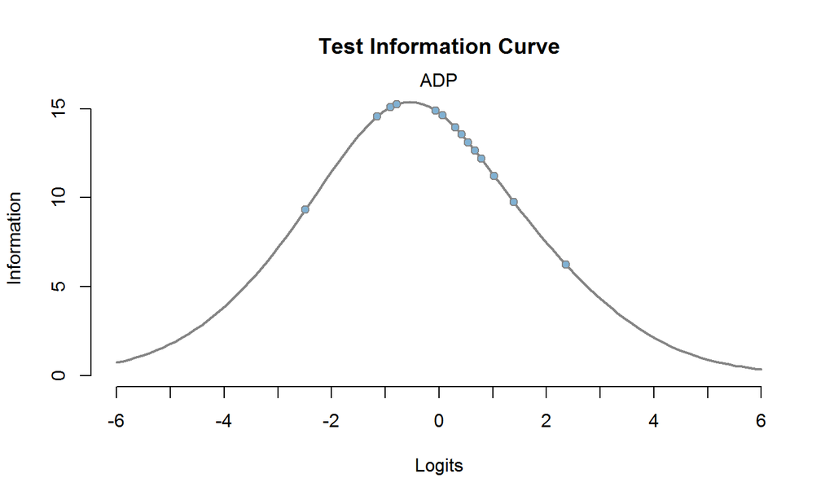

```r
info.graph(ADP, type = "TIC")  # produces one graph
```

## `info.graph()` cont.

For the item information curves:

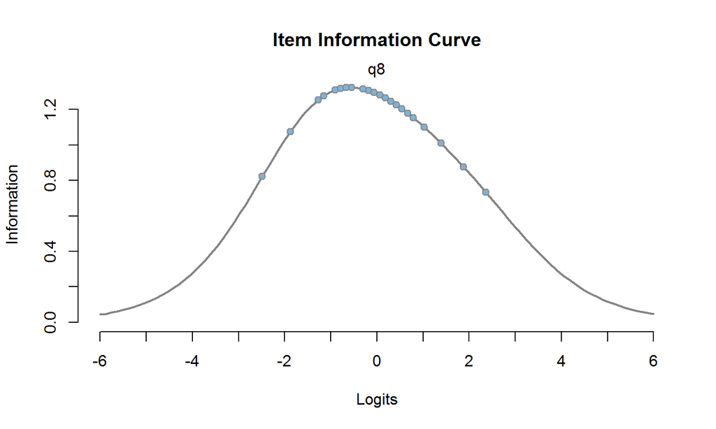

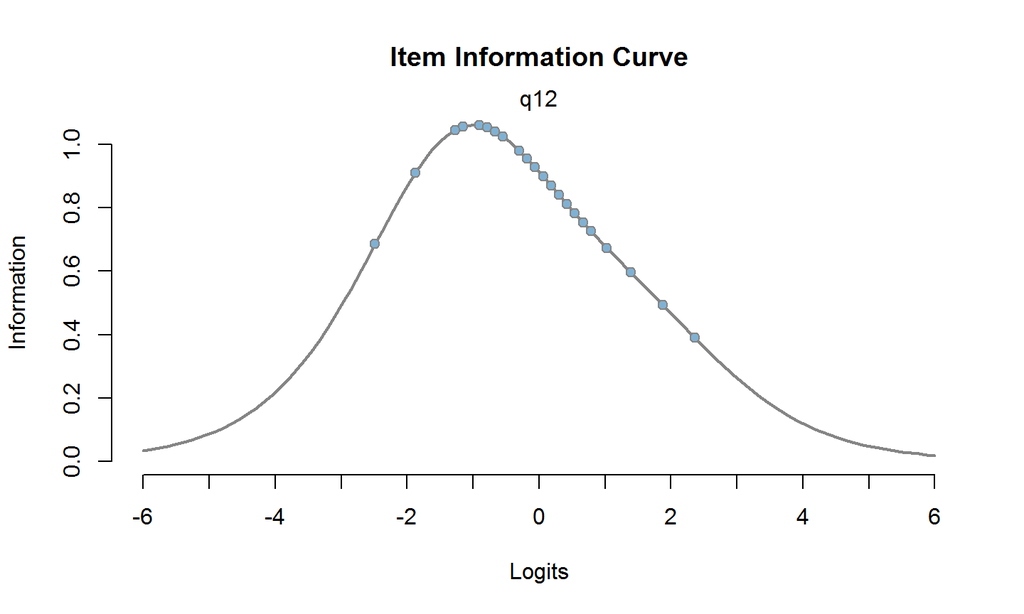

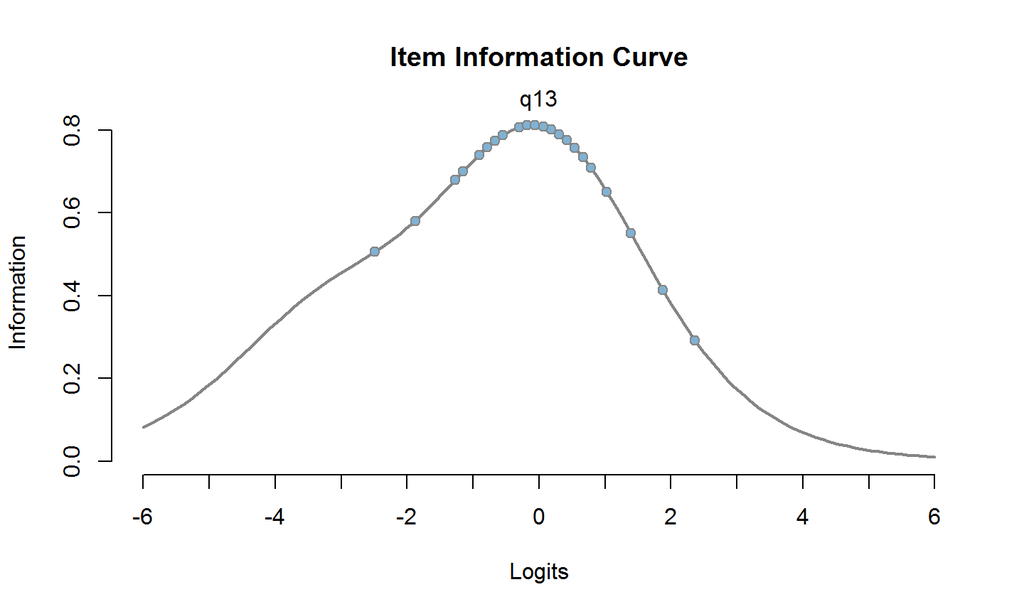

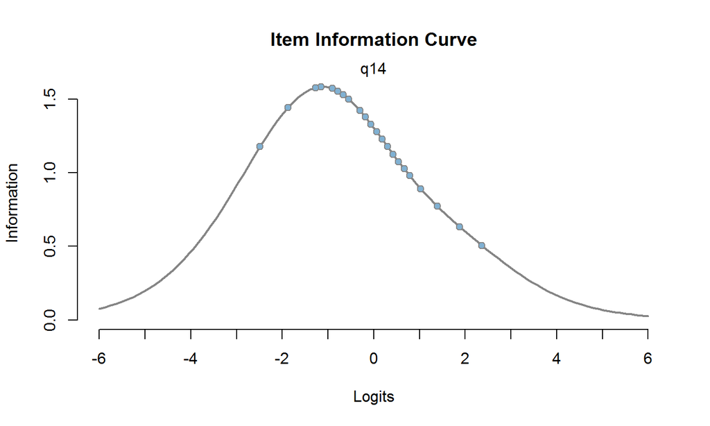

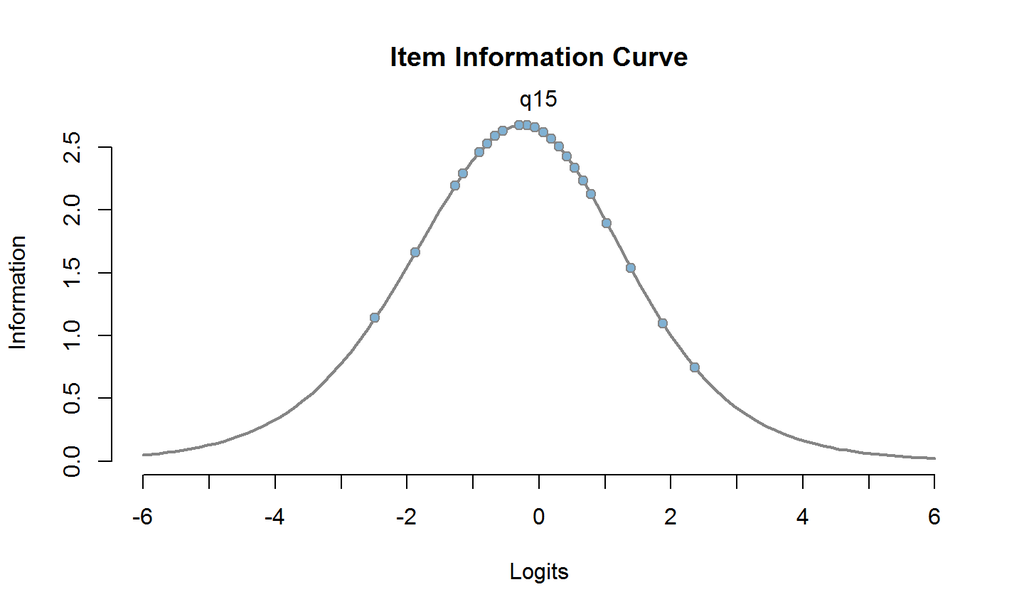

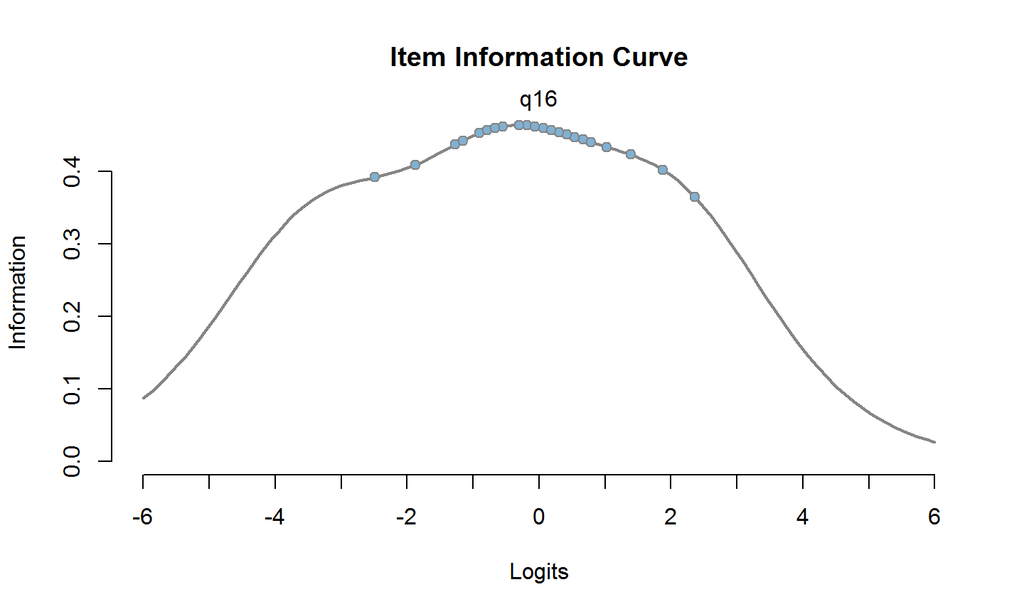

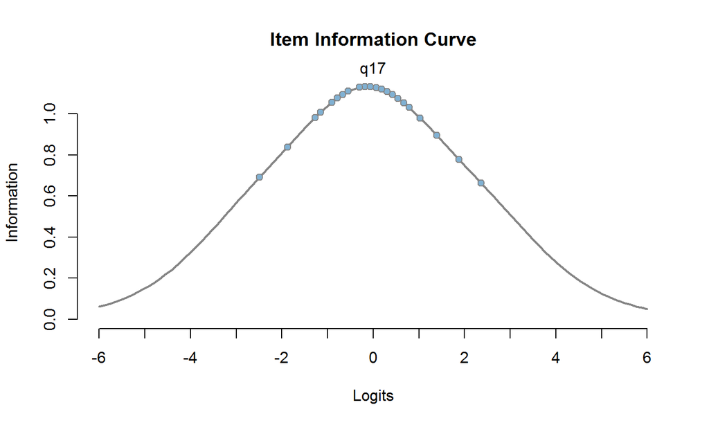

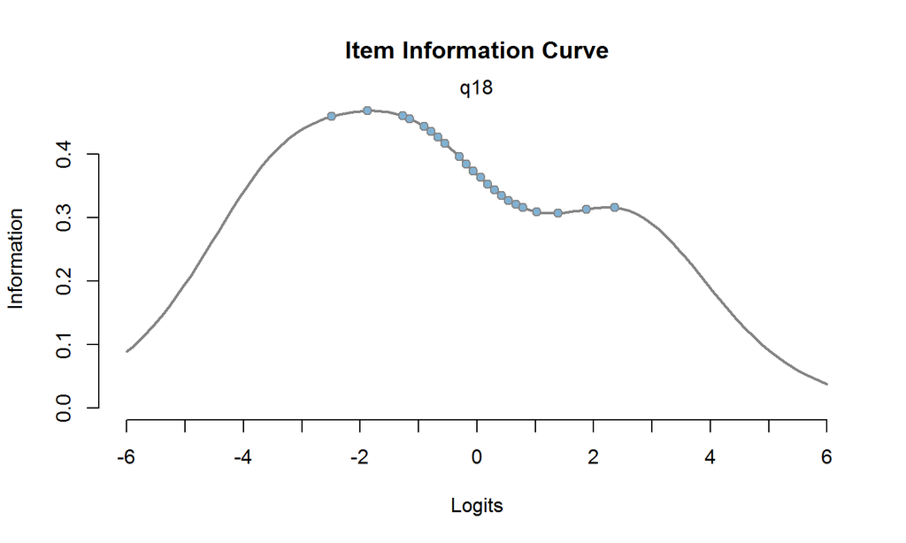

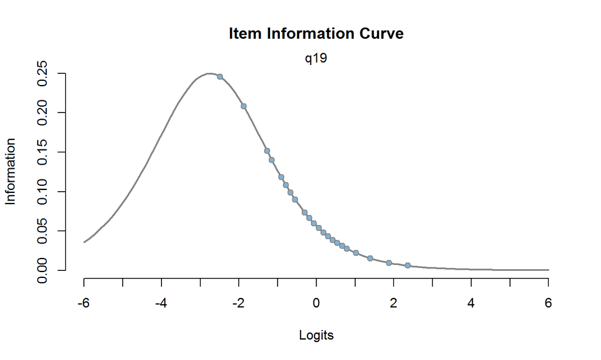

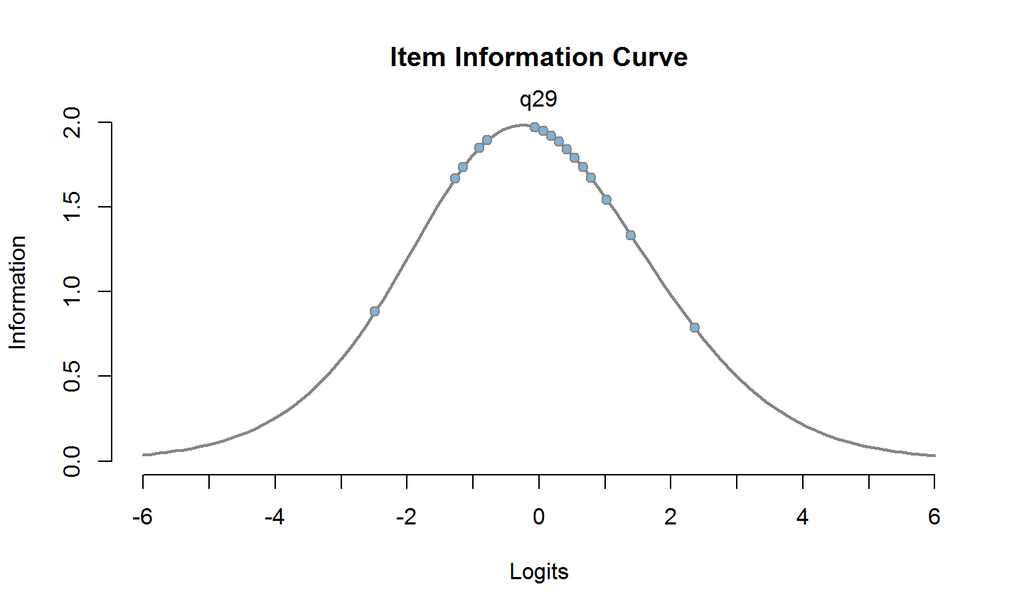

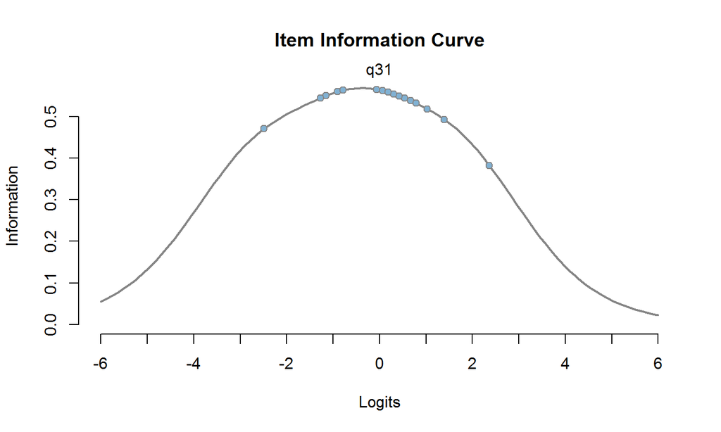

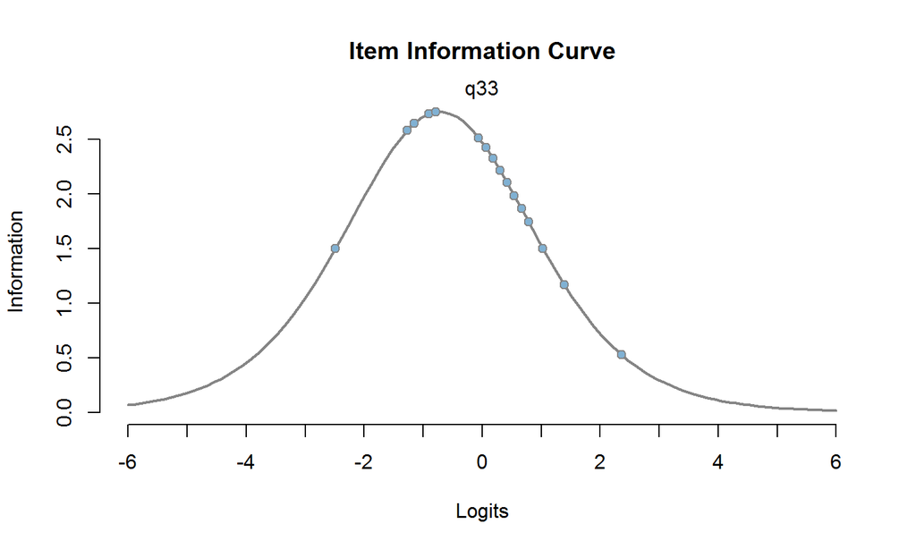

[1 more figures not shown]

```r
info.graph(ADP, type = "IIC")  # produces 1 graph per item!
```

## `wm()`

### A wrapper for the `wrightMap()` function

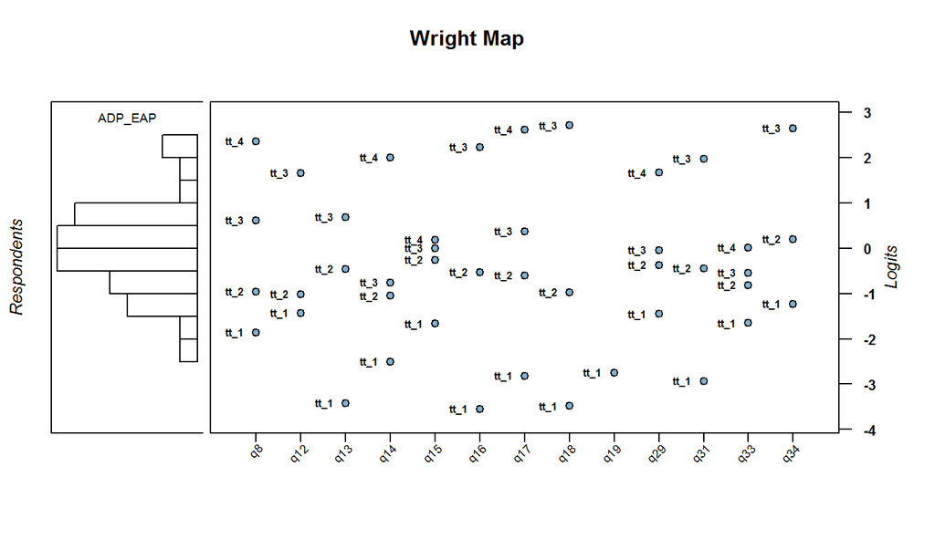

```r
?wm
wm(ADP) # organized in item order
```

## `wm()` cont.

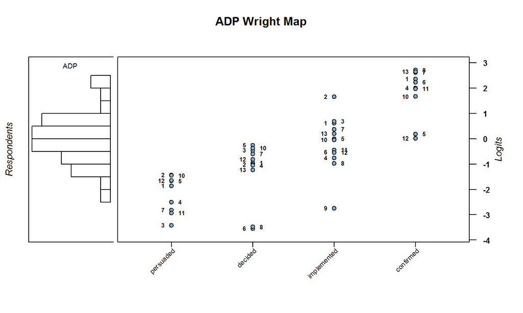

```r
wm(ADP, byCat = TRUE) # organized in construct category order
```

## `wm()` cont.

If you want to customize the output further, see the `wrightMap()` function documentation. The function provided in this package is merely a wrapper.

```r
?wrightMap
```

## `Split.halves()`

### Calculate the split halves reliability coefficient

There is some data preprocessing that needs to happen before runnning `Split.halves()`.

1. You must split your item information and score objects in half.
2. You must run `craschR()` on each half.

```r
item1 = ADPitem[c(2, 5, 7, 8, 10, 11), ]      # selects rows
scores1 = ADPwide[ , c(2, 5, 7, 8, 10, 11)] # selects columns

item2 = ADPitem[c(1, 3, 4, 6, 9, 12, 13), ]
scores2 = ADPwide[ , c(1, 3, 4, 6, 9, 12, 13)]
```

## `Split.halves()` cont.

```r
results1 = craschR(scores1, item1, ADPcons, writeout = FALSE)
results2 = craschR(scores2, item2, ADPcons, writeout = FALSE)

?Split.halves

Split.halves(results1, results2)
```

```
## [1] 0.8272428
```

## `mn.traj()`

### Graph showing mean location trajectories by item

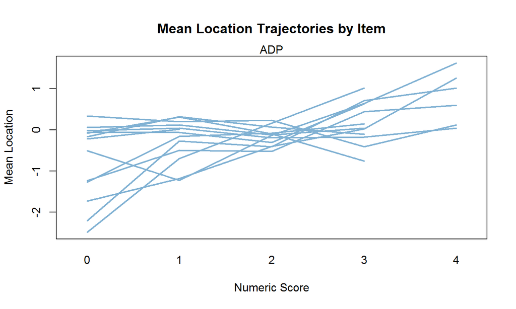

```
## $ADP
## $ADP$meanLocations
##     recodedScore0 recodedScore1 recodedScore2 recodedScore3 recodedScore4
## q8    -0.50213420   -1.22342238   -0.12641800    0.64437974    1.62842309
## q12   -0.16515069    0.32470499    0.07275937   -0.10440032            NA
## q13   -1.27409970   -0.16068275   -0.08129849    0.14962550            NA
## q14   -1.72697535   -1.18269201   -0.40062164    0.02858596    1.25790510
## q15   -1.23844805   -0.49266045   -0.51799558    0.44456878    0.59867153
## q16   -0.05729920   -0.06415945   -0.30251297    0.63901619           NaN
## q17   -2.20781133   -0.27310234   -0.41114276    0.71284641    1.02024823
## q18   -2.48606227   -0.69782660    0.16413973    1.01685327            NA
## q19   -0.21624702    0.02092762           NaN            NA            NA
## q29    0.33903361    0.20399894    0.23140796   -0.40824348    0.12538309
## q31    0.06108846    0.11962695   -0.12002659    0.04460511            NA
## q33   -0.01736083    0.04745682   -0.19008742   -0.17033319    0.04270205
## q34   -0.07655120    0.31138865   -0.09545367   -0.75663495            NA
##
## $ADP$sdLocations
##     recodedScore0 recodedScore1 recodedScore2 recodedScore3 recodedScore4
## q8      0.4886113     0.9264868    0.63569382    0.81102735     0.8814033
## q12     0.4836059     0.3007690    1.12157810    1.36605716            NA
## q13            NA     0.6737309    0.86521143    1.20935790            NA
## q14     1.0735110     0.4517753    0.23908123    0.49746512     0.7815673
## q15     1.1864555     0.4748929    0.61381077    0.09633934     0.8948849
## q16            NA     1.0371572    0.97500103    1.07189046            NA
## q17     0.3935062     0.7816537    0.43967983    0.84169742     1.2644940
## q18            NA     0.6199486    0.75847969    1.24023574            NA
## q19     0.6861177     1.0761928            NA            NA            NA
## q29     1.1635197     0.6331691    0.44356949    0.96102185     1.5184930
## q31     0.4459837     1.1063030    0.86767093    1.37827788            NA
## q33     0.7625745     0.7469289    0.09076741    0.53531004     1.2501678
## q34     0.9084495     1.0006262    1.18587279    0.29875754            NA
```

```r
?mn.traj
mn.traj(ADP)
```

## `Sp.rho()`

### Calculate Spearman's rho

We need fully dichotomous data for this function. A sample data set is provided in the package.

```r
?Sp.rho

DIresults = craschR(scores = DIwide, itemInfo = DIitem,
                    consInfo = DIcons, writeout = FALSE)

Sp.rho(DIresults, expOrder = c(14, 13, 12, 11, 10, 9, 8, 7,
                               6, 5, 4, 3, 2, 1))
```

```
## [1] -0.07040708
```

## Future development

## Future plans

- Write estimation code instead of calling other packages?
- Implement in BASS for reporting
- `mirt` support
- More flexibility/options in available functions:
  - Rating scale model
  - Graphic options (bin size, etc.)
- New functions:
  - DIF
  - Import results from ConQuest, Stata, or other R packages

## Thanks!

aea@berkeley.edu

Thanks to package contributors: David Torres Irribarra, Rebecca Freund, Yukie Toyama, and Mark Wilson

bearcenter.berkeley.edu